# HW2 DATA 622

Rachel Greenlee

3/26/2022

```r
#prevent conflict with skimr and dlookr
options(kableExtra.auto_format = FALSE)

library(skimr)
library(tidyverse)
library(lubridate)
library(rpart) #decision tree package rec'd by Practical ML in R textbook
library(rpart.plot) #decision tree display package rec'd by Practical ML in R textbook
library(randomForest) #for random forest modeling
library(caret) #for confusionMatrix()
```

# Assignment Prompt

### (a) Based on the latest topics presented, bring a dataset of your choice and create a Decision Tree where you can solve a classification or regression problem and predict the outcome of a particular feature or detail of the data used.

I’m choosing to use a dataset showing the relationship between physiological parameters and stress level of an individual from Kaggle. The direct link to the dataset is below:

https://www.kaggle.com/datasets/laavanya/stress-level-detection?select=Stress-Lysis.csv

This is a dataset with 2001 cases and 4 variables. There are 3 variables I’ve imported as numeric: `humidity`, `temp`, and `steps` - these are relevant to the individuals. There are no missing values. I’ve imported my target variable, `stress_lvl` as a factor and it has three levels that correspond to low (0), medium (1), and high (2).

All appear to be reasonable distributed from looking at the percentiles.I note that an average humdity value is 20, average temp is 89, and average steps are about 100.

```r
stress <- read.csv("stress.csv",
                 col.names = c("humidity", "temp", "steps", "stress_lvl"),
                 colClasses = c("numeric", "numeric", "numeric", "factor"))

skim(stress)
```

Data summary

| Name | stress |
| --- | --- |
| Number of rows | 2001 |
| Number of columns | 4 |
| _______________________ |  |
| Column type frequency: |  |
| factor | 1 |
| numeric | 3 |
| ________________________ |  |
| Group variables | None |

**Variable type: factor**

| skim_variable | n_missing | complete_rate | ordered | n_unique | top_counts |
| --- | --- | --- | --- | --- | --- |
| stress_lvl | 0 | 1 | FALSE | 3 | 1: 790, 2: 710, 0: 501 |

**Variable type: numeric**

| skim_variable | n_missing | complete_rate | mean | sd | p0 | p25 | p50 | p75 | p100 | hist |
| --- | --- | --- | --- | --- | --- | --- | --- | --- | --- | --- |
| humidity | 0 | 1 | 20.00 | 5.78 | 10 | 15 | 20 | 25 | 30 | ▇▇▇▇▇ |
| temp | 0 | 1 | 89.00 | 5.78 | 79 | 84 | 89 | 94 | 99 | ▇▇▇▇▇ |
| steps | 0 | 1 | 100.14 | 58.18 | 0 | 50 | 101 | 150 | 200 | ▇▇▇▇▇ |

Before we begin modeling I will split this dataset into a test/train set and check the class distribution of my target variable `stress_lvl`.

```r
#split into test/train set
set.seed(3190)
sample_set <- sample(nrow(stress), round(nrow(stress)*0.75), replace = FALSE)
stress_train <- stress[sample_set, ]
stress_test <- stress[-sample_set, ]
```

Checking the class proportion tables bth the training and testing dataset seem to have roughly the same proportion of stress levels as the original data, so I can proceed with model building.

```r
round(prop.table(table(select(stress, stress_lvl), exclude = NULL)), 4) * 100
```

```
##
##     0     1     2
## 25.04 39.48 35.48
```

```r
round(prop.table(table(select(stress_train, stress_lvl), exclude = NULL)), 4) * 100
```

```
##
##     0     1     2
## 24.85 39.64 35.51
```

```r
round(prop.table(table(select(stress_test, stress_lvl), exclude = NULL)), 4) * 100
```

```
##
##    0    1    2
## 25.6 39.0 35.4
```

### (b) Switch variables to generate 2 decision trees and compare the results.

First I’ll attempt making a model to predict the `stress_lvl` based on all 3 of the predictive variables. From the plot it appears that `humidity` is the largest predictor, where a `humidity` measure of less than 15 means the low (0) stress level, between 15-23 is the medium (1) level, and greater than 23 is the high (2) stress level. It appears the other variables weren’t even necessary to build decision tree.

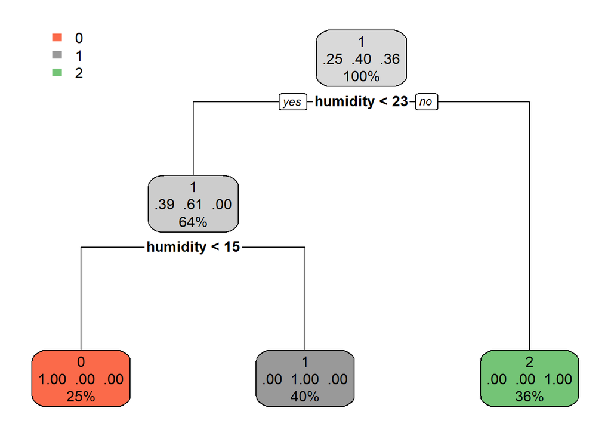

```r
#build model via rpart package
stress_model_stress_lvl <- rpart(stress_lvl ~ .,
                         method = "class",
                         data = stress_train
                          )

#display decision tree
rpart.plot(stress_model_stress_lvl)
```

Out of curiousity, and to create a second decision tree as required, I’ll make another tree but this time be explicity about only using the `temp` and `steps` variables as predictors. In this case, `temp` appears to be the next most valuable predictor, as the `steps` predictor didn’t even make it into the tree. A temperature of less than 84 is predicted to be the low stress level, from 84-92 the medium stress level, and greater than 92 results in the high stress level.

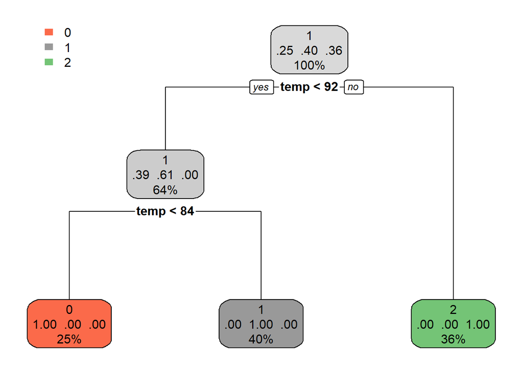

```r
#build model via rpart package
stress_model_tree2 <- rpart(stress_lvl ~ temp + steps,
                            data = stress_train
                          )

#display decision tree
rpart.plot(stress_model_tree2)
```

### (c) Create a random forest for regression and analyze the results.

The Random Forest below is built to predict the `stress_level` based off of the 3 predictor variables. Predicting values for the test set and looking at the confusion matrix it appears the Random Forest can predict with 100% accuracy. This isn’t surprising as the data is likely highly correlated, which makes sense with the subject matter. Physical factors in the body both cause and indicate high stress levels.

```r
stress_model_forest <- randomForest(stress_lvl ~ .,
                                    data = stress_train)

forest_pred <- predict(stress_model_forest, stress_test)

confusionMatrix(forest_pred, stress_test$stress_lvl)
```

```
## Confusion Matrix and Statistics
##
##           Reference
## Prediction   0   1   2
##          0 128   0   0
##          1   0 195   0
##          2   0   0 177
##
## Overall Statistics
##
##                Accuracy : 1
##                  95% CI : (0.9926, 1)
##     No Information Rate : 0.39
##     P-Value [Acc > NIR] : < 2.2e-16
##
##                   Kappa : 1
##
##  Mcnemar's Test P-Value : NA
##
## Statistics by Class:
##
##                      Class: 0 Class: 1 Class: 2
## Sensitivity             1.000     1.00    1.000
## Specificity             1.000     1.00    1.000
## Pos Pred Value          1.000     1.00    1.000
## Neg Pred Value          1.000     1.00    1.000
## Prevalence              0.256     0.39    0.354
## Detection Rate          0.256     0.39    0.354
## Detection Prevalence    0.256     0.39    0.354
## Balanced Accuracy       1.000     1.00    1.000
```

### (d) Based on real cases where desicion trees went wrong, and ‘the bad & ugly’ aspects of decision trees (https://decizone.com/blog/the-good-the-bad-the-ugly-of-using-decision-trees), how can you change this perception when using the decision tree you created to solve a real problem?

In reading this article and thinking about the dataset I chose, I find the decision trees most helpful in this case. Because the data was very simple, had few variables, and was highly correlated - it was most valuable to learn that humidity was the biggest predictor of stress level, and to see those cut-off levels of humidity that corresponded to the low, medium, and high stress levels.